# R review

### Vectores

Los vectores son, sin lugar a dudas, la familia de tipos de datos mas importantes de R. De manera general, hay dos tipos de vectores: los atómicos y las listas. La principal diferencia entre éstos es que todos los elementos de los vectores atómicos deben poseer el mismo tipo de datos, mientras que en las listas pueden variar. Todos los vectores pueden tener atributos. Siendo la clase y la dimensión dos atributos particularmente relevantes.

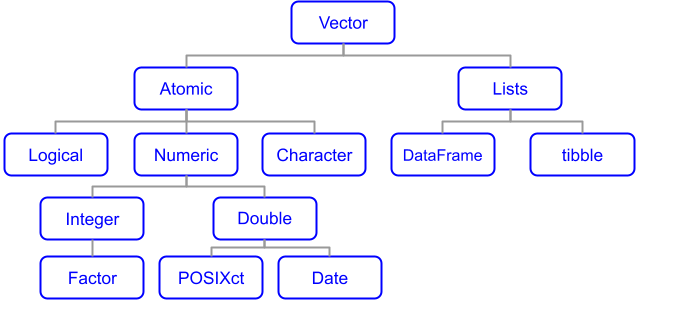

Fig.1 - Vectores en R

#### Vectores atómicos

```r
types <- list(
'lgl_v' = c(T, F),
'int_v' = c(1L, 2L),
'dbl_v' = c(1, 2, 3.5),
'chr_v' = c('Hello World!'))
map_chr(types, typeof)
```

```
##       lgl_v       int_v       dbl_v       chr_v
##   "logical"   "integer"    "double" "character"
```

Podemos especificar valores nulos con `NA` y verificar la existencia de los mismos con `ìs.na`. Recordar que los valores nulos rompen la lógica aritmética.

```r
x <- c(5, NA, NA, 10)
cat(mean(x), '\n')
```

```
## NA
```

```r
cat(x == NA, '\n')
```

```
## NA NA NA NA
```

```r
cat(x + 5, '\n')
```

```
## 10 NA NA 15
```

Los atributos de los vectores pueden ser especificados con la función `attr`.

```r
x <- c(1, 2, 3)
attr(x, 'x_sub') <- c('este', 'es', 'un', 'atributo')
attr(x, 'len') <- length(x)
cat(str(x), '\n')
```

```
##  num [1:3] 1 2 3
##  - attr(*, "x_sub")= chr [1:4] "este" "es" "un" "atributo"
##  - attr(*, "len")= int 3
##
```

De la misma manera, se pueden definir los nombres ya sea utilizando la función `names` o `setNames`.

```r
x <- c(1, 2, 3)
y <- x
names(x) <- c('1', '2', '3')
setNames(y, c('1', '2', '3'))
```

```
## 1 2 3
## 1 2 3
```

Finalmente, podemos acceder a la dimensión de un vector usando la función `dim`.

```r
x <- c(1, 2, 3, 4, 5, 6)
dim(x) <- c(2, 3)
x
```

```
##      [,1] [,2] [,3]
## [1,]    1    3    5
## [2,]    2    4    6
```

#### Listas

Como veremos más adelante, las listas en realidad son una colección de referencias a objetos. Por lo mismo, técnicamente hablando, todas las entradas de una lista son del mismo tipo. Esto nos da la posibilidad de asignar objetos de tipo arbitrario a dichas referencias.

```r
l1 <- list(c(1, 2, 3, 4, 5, 6),
           'Hola Mundo',
           c(T, F, T, T),
           c(1.25, 3.33))
map_chr(l1, typeof)
```

```
## [1] "double"    "character" "logical"   "double"
```

#### Data Frames & Tibbles

Si estás trabajando con datos dentro de R, lo más probable es que utilices Data Frames. Los Data Frames son listas de vectores con atributos especiales para los nombres, nombres de filas y clase. Acompañada de esta clase, tenemos las Tibbles que, en realidad, son Data Frames con algunas modificaciones.

```r
df1 <- data.frame(x = 1:3, y=letters[1:3])
df2 <- tibble(x = 1:3, y = letters[1:3])
cat(typeof(df1), '\n')
```

```
## list
```

```r
cat(paste0(attributes(df1)), '\n')
```

```
## c("x", "y") data.frame 1:3
```

```r
cat(typeof(df2), '\n')
```

```
## list
```

```r
cat(paste0(attributes(df2)), '\n')
```

```
## c("x", "y") 1:3 c("tbl_df", "tbl", "data.frame")
```

Algunas de las principales ventajas de las tibbles con respecto a los data frames son:

1. No hay conversión automática de caracteres a factores
2. No se modifican de manera automática los nombres no sintácticos
3. No soportan nombres de filas
4. Impresión optimizada

### Indexado

Los operadores para extracción de subconjuntos de colecciones a través de indexado dentro de R son rápidos y poderosos. Tener dominio de éstos permitirá llevar a cabo operaciones complejas con una sintaxis tan sencilla que pocos lenguajes igualan.

- **Enteros positivos** se seleccionan los números que se encuentran en las posiciones especificadas.

```r
x <- c(1.2, 3.5, .14, 7.3)

cat(x[c(1, 3)], '\n')
```

```
## 1.2 0.14
```

```r
cat(x[order(x)], '\n')
```

```
## 0.14 1.2 3.5 7.3
```

```r
cat(x[c(1, 1, 2.3, 3.9)], '\n')
```

```
## 1.2 1.2 3.5 0.14
```

Notar que índices repetidos traerán el mismo elemento, mientras que índices flotantes serán silenciosamente coercionados a enteros.

- **Enteros negativos** se excluyen los elementos seleccionados

```r
x <- c(1.2, 3.5, .14, 7.3)

cat(x[-c(1, 3)], '\n')
```

```
## 3.5 7.3
```

- **Vectores lógicos** Se seleccionan los elementos cuyas entradas evalúen `TRUE`.

```r
x <- c(1.2, 3.5, .14, 7.3)

cat(x[c(T, T, F, T)], '\n')
```

```
## 1.2 3.5 7.3
```

```r
cat(x[x>3], '\n')
```

```
## 3.5 7.3
```

- **Indexador vacío** Regresara el total de los elementos dentro de la colección.

```r
x <- c(1.2, 3.5, .14, 7.3)

cat(x[], '\n')
```

```
## 1.2 3.5 0.14 7.3
```

- **Vectores de caracteres** Si el vector tiene nombres, entonces es posible obtener los elementos dentro de cada etiqueta haciendo referencia explícita a su nombre.

```r
x <- c(1.2, 3.5, .14, 7.3) %>%
  setNames(letters[1:4])

cat(x[c('d', 'c', 'a')], '\n')
```

```
## 7.3 0.14 1.2
```

```r
cat(x[factor('b')], '\n')
```

```
## 1.2
```

Notar que el factor no trae directamente el elemento dentro de su etiqueta; esto se debe a que el factor es tratado como su valor entero y no como su etiqueta.

### Control de flujo

Hay dos tipos de estructuras que permiten controlar el flujo de ejecución en R. Una de ellas son las decisiones y la otra son los bucles.

#### IF

La forma básica de las decisiones en R es la siguiente:

```
if (condition) true_action
if (condition) true_action else false_action
```

Si `condition==TRUE`, entonces se realizará true_action; en cualquier otro caso, se realizará false_action.

```r
x1 <- if (T) 1 else 2
x2 <- if (F) 1 else 2

cat(c(x1, x2), '\n')
```

```
## 1 2
```

En caso de que queramos verificar una condición para cada una de las entradas de un vector, tenemos la versión vectorizada ifelse.

```r
x1 <- 1:20
x2 <- ifelse(x1 %% 3, 'not mult3', 'mult3')

cat(c(x1, x2), '\n')
```

```
## 1 2 3 4 5 6 7 8 9 10 11 12 13 14 15 16 17 18 19 20 not mult3 not mult3 mult3 not mult3 not mult3 mult3 not mult3 not mult3 mult3 not mult3 not mult3 mult3 not mult3 not mult3 mult3 not mult3 not mult3 mult3 not mult3 not mult3
```

Para verificar varias condiciones, podemos hacer uso de un `switch` (case_when es su version vectorizada).

```r
x1 <- sample(letters[1:5], 1)

price <- function(x) {
  switch(x,
       a = 'first place',
       b = 'second place',
       c = 'third place',
       d = 'no price',
       e = 'no price',
       stop('Unknown input')
       )
}

cat(c(x1, price(x1)), '\n')
```

```
## e no price
```

#### Bucles

La forma básica de los bucles en R es la siguiente:

```
for (item in vector) perform_action
```

Hay dos palabras reservadas:

- next: sale de la iteración actual
- break: termina el bucle

```r
largest_possible <- 70
largest_observed <- -1

x1 <- sample(1:100, 30)

for(i in x1){
  if(i < largest_observed) next
  if(i > largest_possible) break
  largest_observed = i
}

cat(largest_observed)
```

```
## 31
```

Uno de los posibles problemas es que este tipo de iteración elimina los atributos de los elementos.

```r
x_dates <- as.Date(c('2021-06-04', '2021-06-05'))
for(d in x_dates){
  cat(d, '\n')
}
```

```
## 18782
## 18783
```

```r
x_dates <- as.Date(c('2021-06-04', '2021-06-05'))
for(d in seq_along(x_dates)){
  cat(x_dates[[d]], '\n')
}
```

```
## 18782
## 18783
```

### Programación funcional

En R, los **funcionales** son funciones que reciben funciones como entrada y devuelven un vector como salida. Una de las principales usos de funcionales dentro de R es para reemplazar bucles: Los ciclos **for** son particularmente poco populares en R, pues se asocian con lento rendimiento. En realidad, tiene mucho que se resolvió este tema con los ciclos en R, sin embargo, muchas veces es lo que se hace dentro del ciclo (copias innecesarias de datos) lo que los vuelve lentos.

El **funcional** más fundamental es `map`. Lo que hace es recibir un vector, y aplica una función pura (sin efectos secundarios, y las salidas exclusivamente dependen de las entradas) a cada una de las entradas.

```r
map(letters[1:5], str_to_upper)
```

```
## [[1]]
## [1] "A"
##
## [[2]]
## [1] "B"
##
## [[3]]
## [1] "C"
##
## [[4]]
## [1] "D"
##
## [[5]]
## [1] "E"
```

Como puede verse, el resultado de la función es una lista, lo que hace que sea bastante general. Si lo que queremos es un vector atómico, entonces podemos usar alguna de las alternativas:

```r
cat(map_chr(mtcars, typeof), '\n')
```

```
## double double double double double double double double double double double
```

```r
cat(map_lgl(mtcars, is.double), '\n')
```

```
## TRUE TRUE TRUE TRUE TRUE TRUE TRUE TRUE TRUE TRUE TRUE
```

```r
cat(map_dbl(mtcars, mean), '\n')
```

```
## 20.09062 6.1875 230.7219 146.6875 3.596563 3.21725 17.84875 0.4375 0.40625 3.6875 2.8125
```

Ahora, ¿qué pasa si queremos aplicar una función mas compleja para la cual no haya una implementación directa en R? Para esto, **purr** nos equipa con un poco de azúcar sintáctico que nos permite definir funciones anónimas al vuelo.

```r
cat(map_int(mtcars, ~ length(unique(.))), '\n')
```

```
## 25 3 27 22 22 29 30 2 2 3 6
```

Notar que hacemos uso de **.** para referirnos a la variable de entrada. En general, podemos referirnos a los argumentos de cualquier función anónima de la siguiente manera:

- Un único argumento **.**.
- Dos argumentos **.x**, **.y**.
- Número arbitrario de argumentos **..1**, **..2**, **..3**, …

Si tenemos estructuras un poco más complicadas, podemos especificar los ejes que queremos extraer, ya sea por nombre o posición.

```r
x <- list(
list(-1, x = 1, y = c(2, 3)),
list(-2, x = 4, y = c(1, 2)),
list(-3, x = 8, y = c(9, 10, 12))
)
cat(map_dbl(x, 'x'), '\n')
```

```
## 1 4 8
```

```r
cat(map_dbl(x, list('y', 2)), '\n')
```

```
## 3 2 10
```

### Data Wrangling

- DATA WRANGLING R for Data Science
- PURR EXAMPLE ONE MODEL PER GROUP

### Uso de memoria

Recordemos que en R, el símbolo de asignación por excelencia esta dado por `<-`. De esta manera, cuando ejecutamos:

```r
x <- c('Hola', 'Mundo', '!')
```

se creara el objeto `c('Hola', 'Mundo', '!')` y le se le agrega una referencia a la etiqueta ‘x’. Del mismo modo, al ejecutar

```r
y <- x
```

simplemente, se estará indicando que el objeto puede ser referenciado tanto por ‘x’ como por ‘y’.

```r
obj_addr(x)
```

```
## [1] "0x7f9a992b1df8"
```

```r
obj_addr(y)
```

```
## [1] "0x7f9a992b1df8"
```

Este tipo de mecanismos se utilizan para llevar un manejo de memoria mas eficiente. Sin embargo, cuando se hace una modificación a uno de los objetos, digamos `y[[3]] <- 4`, veremos que:

```r
y[[3]] <- 4
obj_addr(y)
```

```
## [1] "0x7f9a9a180d08"
```

Esto quiere decir que los objetos en R son inmutables. Una vez creados, cada vez que se realice una modificación, el objeto será duplicado. En caso de que estuviéramos interesados en conocer toda la historia de un objeto, podemos usar la funcion `tracemem()`.

```r
x <- c('Hola', 'Mundo', '!')
cat(tracemem(x), '\n')
```

```
## <0x7f9a9a3ddc08>
```

```r
y <- x
y[[3]] <- 4
```

```
## tracemem[0x7f9a9a3ddc08 -> 0x7f9a9a463ea8]: eval eval withVisible withCallingHandlers handle timing_fn evaluate_call <Anonymous> evaluate in_dir block_exec call_block process_group.block process_group withCallingHandlers process_file <Anonymous> <Anonymous>
```

En el caso de las listas, lo que tenemos es que cada entrada hace referencia a un elemento. Por tanto, las listas almacenan referencias a objetos.

```r
l1 <- list(1, 2, 3)
l2 <- l1
l2[[3]] <- 4
cat(obj_addr(l1))
```

```
## 0x7f9ade6174f8
```

```r
cat(obj_addr(l2))
```

```
## 0x7f9a9984c438
```

```r
cat(map_chr(l1, ~obj_addr(.))) # Esto tambien lo podrian hacer con ref
```

```
## 0x7f9a9a5be2a0 0x7f9a9a5be268 0x7f9a9a5be230
```

```r
cat(map_chr(l2, ~obj_addr(.)))
```

```
## 0x7f9a9a5be2a0 0x7f9a9a5be268 0x7f9a9a5be150
```

Noten que estas son copias someras, es decir, sólo la referencia al objeto es copiada, no las referencias existentes dentro del objeto.

Las dataframes son listas de vectores, por tanto, las implicaciones del ‘copia cuando modifica’ son importantes. Por ejemplo, cuando se modifica una columna, solo la referencia a esa columna debe cambiar, mientras que si se modifica una fila, todas las referencias deben cambiar.

Finalmente, los caracteres son referenciados por una tabla global de caracteres

```r
l1 <- list('Hola', 'Mundo', 'Hola', 'Mundo', '!')
ref(l1, character=TRUE)
```

```
## █ [1:0x7f9a8e4d6878] <list>
## ├─█ [2:0x7f9a8e445b58] <chr>
## │ └─[3:0x7f9a99282758] <string: "Hola">
## ├─█ [4:0x7f9a8e445b20] <chr>
## │ └─[5:0x7f9a992826b0] <string: "Mundo">
## ├─█ [6:0x7f9a8e445ae8] <chr>
## │ └─[3:0x7f9a99282758]
## ├─█ [7:0x7f9a8e445ab0] <chr>
## │ └─[5:0x7f9a992826b0]
## └─█ [8:0x7f9a8e445a78] <chr>
##   └─[9:0x7f9add80ee80] <string: "!">
```

**Ejercicio:**

Si definimos a ‘x’ como

```r
x <- runif(1e6)
```

y hacemos ‘y’

```r
y <- list(x, x, x, x, x)
```

Explica el siguiente resultado

```r
cat(obj_size(x), '\n')
```

```
## 8000048
```

```r
cat(obj_size(y), '\n')
```

```
## 8000144
```

Existen dos excepciones al ‘copia cuando modifica’; éstas son:

- Cuando el objeto tiene una única etiqueta.
- Los ambientes siempre se modifican en sitio.